# Multiple Imputation

2022-05-16

## Multiple imputation

## Multiple imputation idea

- Imputing the missing data entries with multiple “plausible” values.
- Takes imputation uncertainty into account
- A method to improve the main **analysis results**, *so having a fully observed data set is not the goal*.
  - Unbiased estimates
  - More precision and thus power
- R package: `mice`

## Multiple Imputation process

- Imputation phase
- Analysis phase
- Pooling phase
1. Incomplete data
2. Generate multiple copies of the same dataset, but each time differenty imputed values
3. Analyze each imputed dataset
4. Pool results for analyses to final study result

## Multiple Imputation process

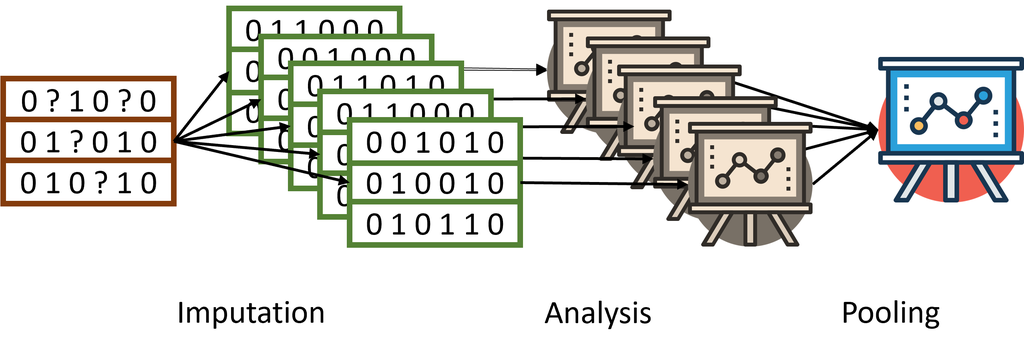

## Imputation phase

- Imputing the missing data entries with multiple “plausible” values
- Specify the **imputation model**
  - method to estimate imputed values
  - predictors used in the model
  - *can both be specified for each variable with missing data*

## Algorithm for imputations

Fully Conditional Specification (FCS): imputes variable-by-variable.

- For each variable the imputation model can be different:
  - method
  - predictors
- Flexible method and allows imputations close to the data

Joint modelling: imputes from a multivariate distribution.

- Computationally less intensive.
- Good theoretical unterpinnings, provided that the model fits well with the data.

`mice` uses FCS

## General method FCS

Per variable with missing data:

- Impute missing value by using the predicted value estimated from observed data.
- Add residual error to simulate sampling error
- Depending on the variable type that needs to be imputed, the imputation method is defined.

> Later more on methods

## Predictors for imputation

Imputation model = method + predictors

- For each variable, the most relevant *predictors* can be indicated
- Use variables that are in the analysis model also in the imputation model (compatibility)
- Add *auxiliary variables*
- Advice to use no more than 25 predictors (also depends on sample size)

*Auxiliary variables*: variables related to the probability of missing data or to the variable with missing data.

## Iterations

- One iteration = one cycle through all variables that need to be imputed.
  - The algorithm starts with a random draw from the observed data.
  - Then imputes the incomplete data in a variable-by-variable fashion.
- Typically 5 to 10 iterations before an imputed data set is generated.
- Iterations are repeated to ensure convergence of the algorithm

## Iterations for data set 1

**Iterations for generating the imputations for *Solar.R* in the first data set:**

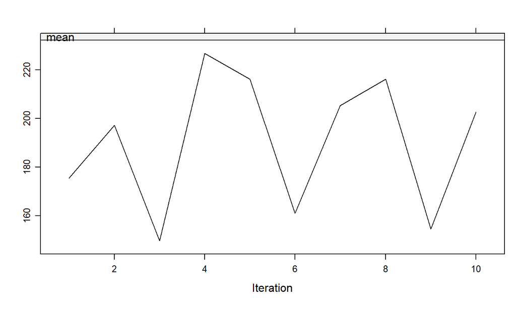

## Iterations for data set 2

**Iterations for generating the imputations for *Solar.R* in the second data set:**

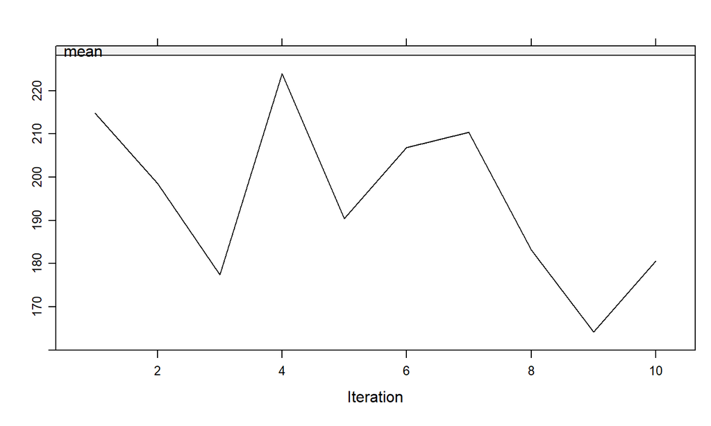

## Iterations for 5 imputed datasets

**Iterations for generating the imputations for *Solar.R* in all five data sets:**

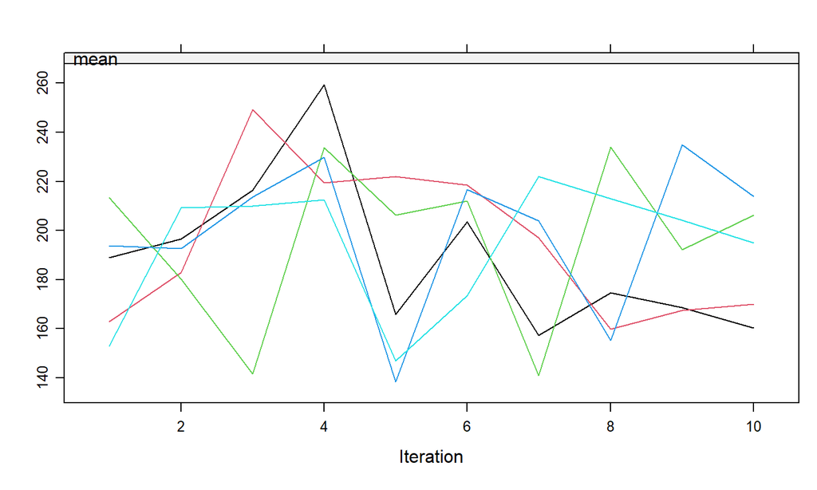

## Convergence check

### airquality illustration

- Check the convergence of the algorithm for all imputed variables

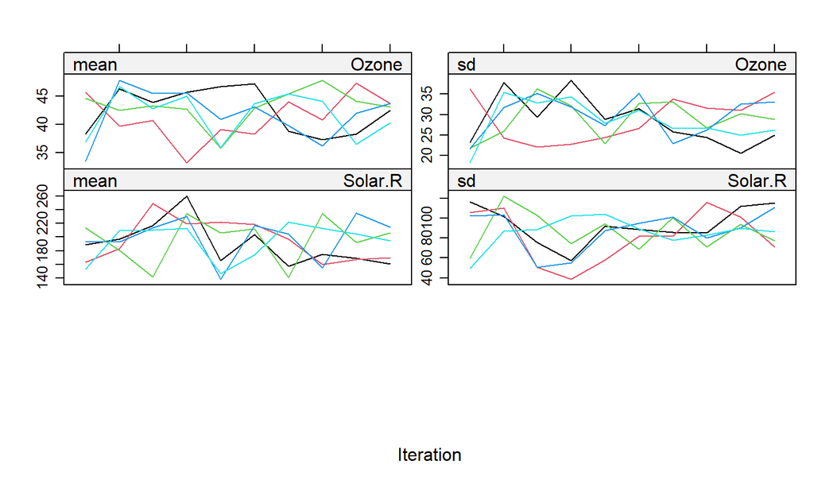

```r
imp <- mice(airquality, maxit = 10, print = F)
plot(imp)
```

## Convergence check

### airquality illustration

- Use additional iterations when in doubt if convergence is reached

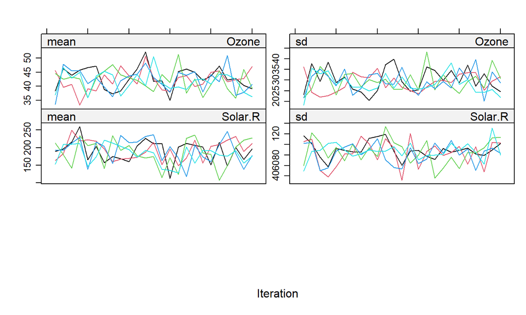

```r
imp <- mice(airquality, maxit = 25, print = F)
plot(imp)
```

## Convergence check

### boys illustration

- Convergence may need more iterations

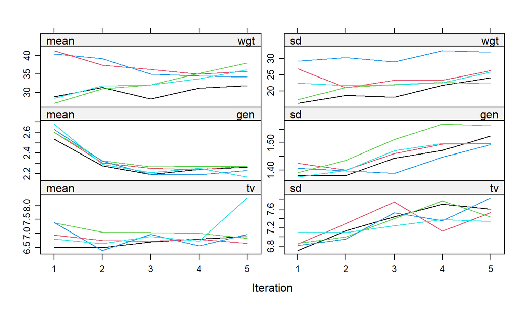

```r
imp <- mice(boys, print = F)
plot(imp, c("wgt", "gen", "tv"))
```

## Convergence check

### boys illustration

- Looks better for gen and tv, but there seems to be a problem for wgt.

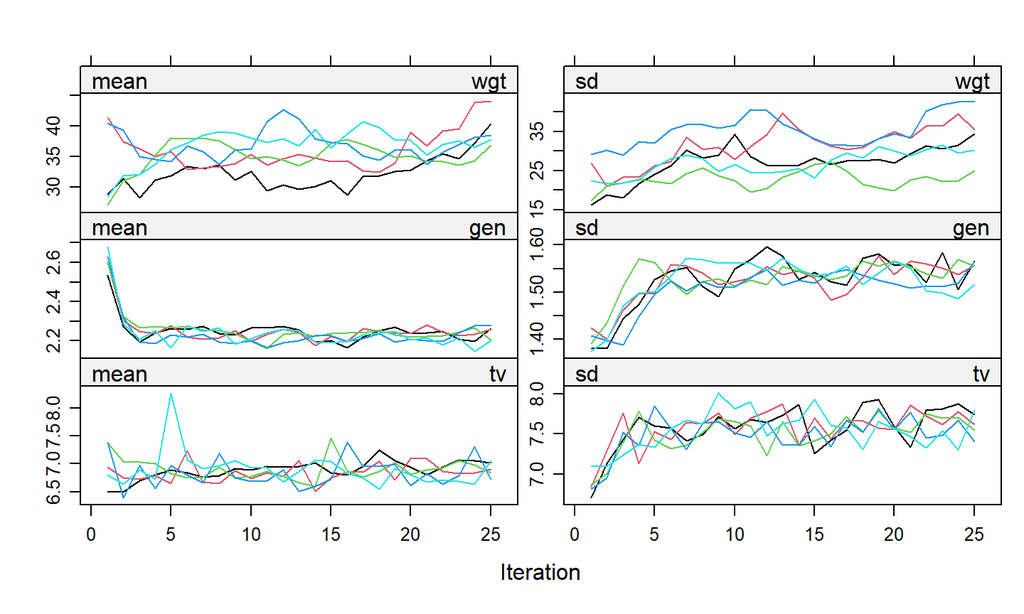

```r
imp <- mice(boys, maxit = 25, print = F)
plot(imp, c("wgt", "gen", "tv"))
```

## Adapting imputation model

- Changes in imputation model may be needed when:
  - Two variables are highly correlated (multi-collinearity)
  - A variable with so many missing values that the imputations are unstable

## Number of imputations

- Theoretically, higher \(m\) is better.
- Usually, use \(m = 5\) for model building and \(m\) *~ % missing data* for final analysis.
- In lower \(m\) the between-imputation-variance is enlarged by \(\frac{1}{m}\) before computing the total variance.

## Analysis phase

- Each imputed data set is analyzed, with the substantive analysis model
- This results in \(m\) sets of results
- Workflow:
  - Imputation
  - **Analysis**
  - Pooling

## Analysis example

```r
imp_pmm <- mice(airquality, method = "pmm", print = F)
fit <- with(imp_pmm, lm(Ozone ~ Solar.R))

summary(fit)
```

```
## # A tibble: 10 x 6
##    term        estimate std.error statistic   p.value  nobs
##    <chr>          <dbl>     <dbl>     <dbl>     <dbl> <int>
##  1 (Intercept)  24.8       5.71        4.34 0.0000258   153
##  2 Solar.R       0.0996    0.0278      3.58 0.000455    153
##  3 (Intercept)  21.7       5.62        3.85 0.000173    153
##  4 Solar.R       0.105     0.0271      3.88 0.000153    153
##  5 (Intercept)  21.3       5.53        3.86 0.000165    153
##  6 Solar.R       0.103     0.0267      3.87 0.000164    153
##  7 (Intercept)  21.8       5.55        3.93 0.000127    153
##  8 Solar.R       0.109     0.0271      4.02 0.0000930   153
##  9 (Intercept)  20.0       5.55        3.60 0.000433    153
## 10 Solar.R       0.112     0.0271      4.14 0.0000578   153
```

## Pooling phase

- Pool the analysis results to obtain final parameter estimates.
- For normally distributed parameters: **Rubin’s Rules**

## Rubin’s Rules

- Pooling of point estimates that are normally distributed over the imputed datasets.
- Means, standard deviations, regression estimates, linear predictors, proportions.
- For pooling point estimates, use mean:

  > \(\hat\theta = \frac{1}{m} \sum^m_{i=1}{\theta_i}\)
- Pooling of variance or standard error around the estimate: combine the within and between imputation variance.

## Variance pooling Rubins Rules

Between variance:

> \(\sigma^2_{between} = \frac{\sum^m_{i=1}(\beta_i - \overline\beta)^2}{m-1}\)

Within variance:

> \(\sigma^2_{within} = \frac{\sum^m_{i=1}\sigma^2_i}{m}\)

**Total variance:**

> \(\sigma^2_{total} = \sigma^2_{within} + \sigma^2_{between} + \frac{\sigma^2_{between}}{m}\)

## Pooling of non-normal parameters

- Use a transformation to approximate a normal distribution
- Examples:
  - Correlation: Fisher \(z\)
  - Odds Ratio, Relative Risk, Hazard ratio: log transformation
  - Explained variance: Fisher \(z\) for \(\sqrt{R^2}\)

## Pooling example

```r
imp_pmm <- mice(airquality, method = "pmm", print = F)
fit_mi <- with(imp_pmm, lm(Ozone ~ Solar.R))

pool(fit_mi)
```

```
## Class: mipo    m = 5
##          term m   estimate         ubar            b            t dfcom
## 1 (Intercept) 5 21.9250591 3.128523e+01 3.114620e+00 3.502277e+01   151
## 2     Solar.R 5  0.1057732 7.371338e-04 2.371589e-05 7.655929e-04   151
##          df        riv     lambda       fmi
## 1  96.54006 0.11946675 0.10671755 0.1246657
## 2 136.72129 0.03860773 0.03717258 0.0509547
```

## Pool output

- **riv**: Relative increase in variance due to nonresponse
- **df**: Residual degrees of freedom for hypothesis testing
- **lambda**: Proportion of total variance due to missingness
- **fmi**: Fraction of missing information for the parameter estimates

## Imputation methods

## Multiple imputation process

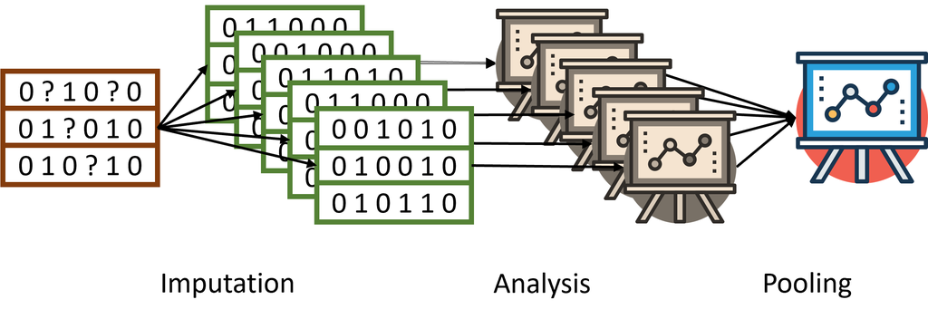

In the imputation phase, imputed values are estimated using an *imputation method*.

## Methods for continuous variables

- Regression imputation: `norm.predict`
- Stochastic regression imputation (regression + residual error): `norm.nob`
- Stochastic regression with parameter uncertainty: `norm`
- Predictive mean matching: `pmm`

## Example data

### airquality

|  | vars | n | mean | sd | median | trimmed | mad | min | max | range | skew | kurtosis | se |
| --- | --- | --- | --- | --- | --- | --- | --- | --- | --- | --- | --- | --- | --- |
| Ozone | 1 | 116 | 42.129310 | 32.987884 | 31.5 | 37.797872 | 25.94550 | 1.0 | 168.0 | 167 | 1.2098656 | 1.1122431 | 3.0628482 |
| Solar.R | 2 | 146 | 185.931507 | 90.058422 | 205.0 | 190.338983 | 98.59290 | 7.0 | 334.0 | 327 | -0.4192893 | -1.0040581 | 7.4532881 |
| Wind | 3 | 153 | 9.957516 | 3.523001 | 9.7 | 9.869919 | 3.40998 | 1.7 | 20.7 | 19 | 0.3410275 | 0.0288647 | 0.2848178 |
| Temp | 4 | 153 | 77.882353 | 9.465270 | 79.0 | 78.284553 | 8.89560 | 56.0 | 97.0 | 41 | -0.3705073 | -0.4628929 | 0.7652217 |
| Month | 5 | 153 | 6.993464 | 1.416522 | 7.0 | 6.991870 | 1.48260 | 5.0 | 9.0 | 4 | -0.0023448 | -1.3167465 | 0.1145191 |
| Day | 6 | 153 | 15.803922 | 8.864520 | 16.0 | 15.804878 | 11.86080 | 1.0 | 31.0 | 30 | 0.0026001 | -1.2224406 | 0.7166540 |

## Regression imputation

### Concept

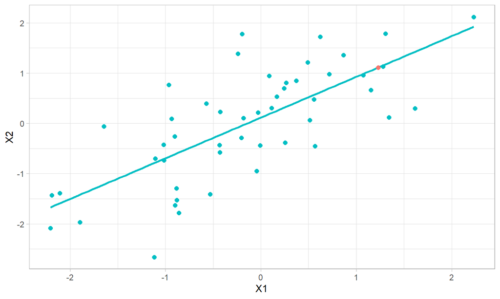

## Regression imputation

### Univariate imputation

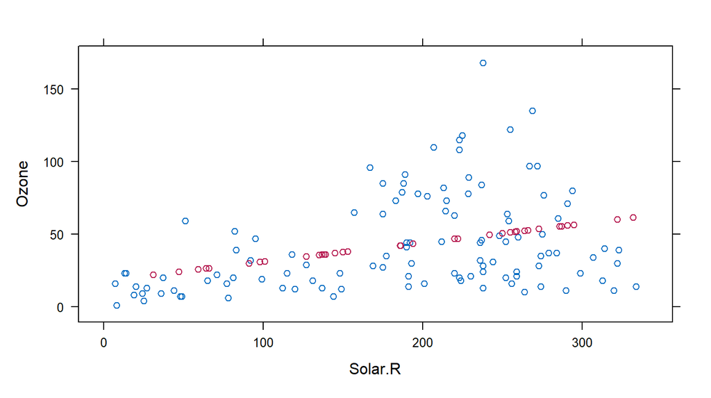

```r
imp_reg <- mice(airquality %>% select(Ozone, Solar.R), method = "norm.predict", print = F)
xyplot(imp_reg, Ozone ~ Solar.R)
```

## Regression imputation

### Multivariate imputation

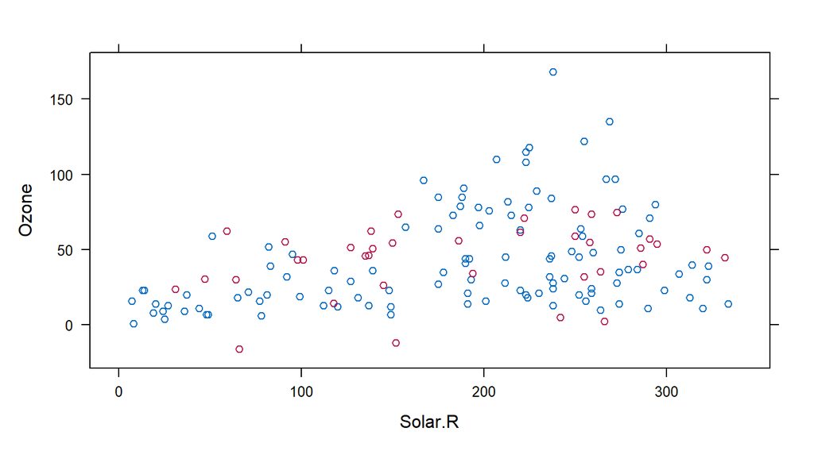

```r
imp_reg <- mice(airquality,  method = "norm.predict", print = F)
xyplot(imp_reg, Ozone ~ Solar.R)
```

## Stochastic regression imputation

### Algorithm

- Imputed value: \(Y_{imp} = \hat{\beta}_0 + X_{mis}\hat{\beta}_1 + \epsilon\)
- Parameters \(\hat{\beta}_0\) and \(\hat{\beta}_1\) are estimated from the observed data.
- *And updated after the first imputation with the imputed data.*
- \(\epsilon\) is normally distributed residual error

## Stochastic regression imputation

### Concept

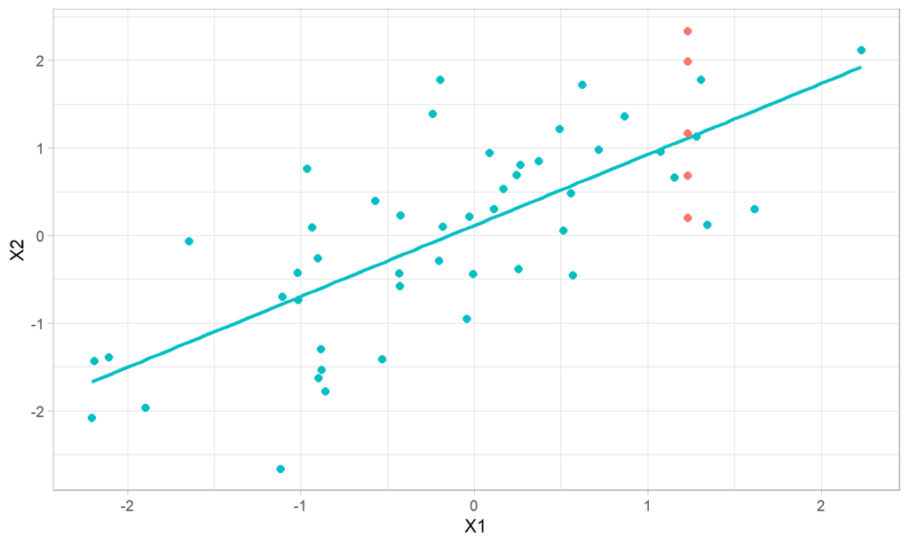

## Stochastic regression imputation

### Univariate

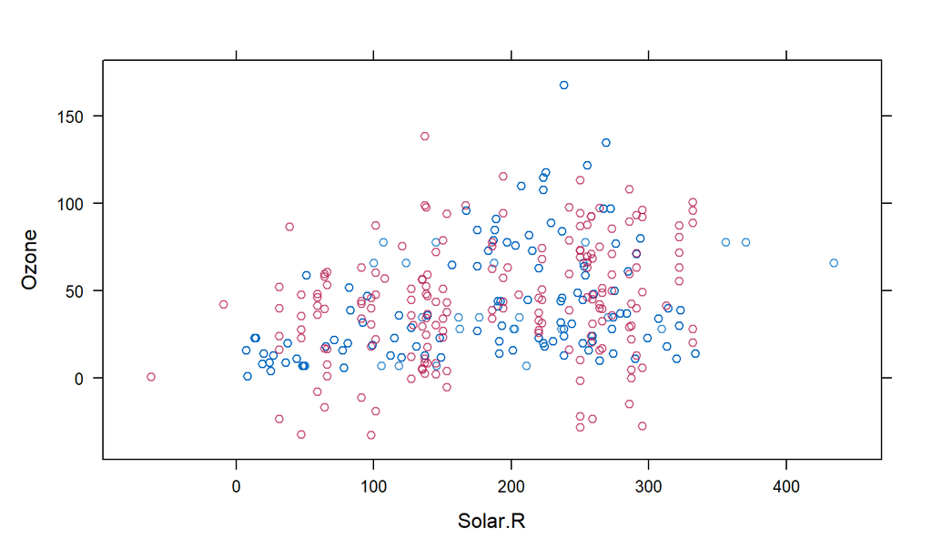

```r
imp_reg <- mice(airquality %>% select(Ozone, Solar.R), method = "norm.nob", print = F)
xyplot(imp_reg, Ozone ~ Solar.R)
```

## Stochastic regression imputation

### Multivariate

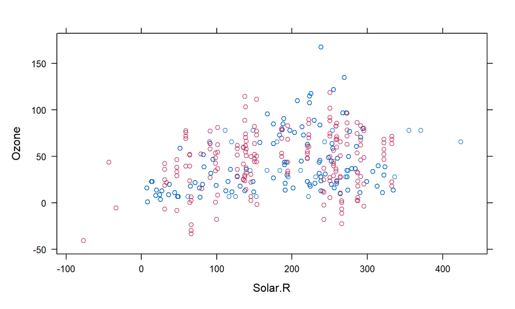

```r
imp_reg <- mice(airquality, method = "norm.nob", print = F)
xyplot(imp_reg, Ozone ~ Solar.R)
```

## Bayesian regression imputation

### Algorithm

- Imputed value: \(Y_{imp} = \dot{\beta}_0 + X_{mis}\dot{\beta}_1 + \epsilon\)
- Parameters \(\dot{\beta}_0\) and \(\dot{\beta}_1\) are drawn from their posterior distribution.
- \(\epsilon\) is normally distributed residual error

## Bayesian regression imputation

### Concept

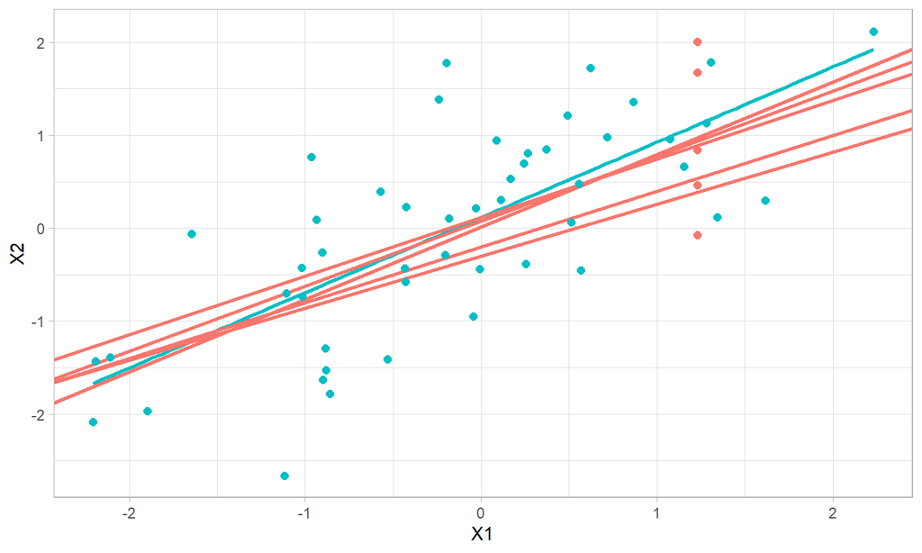

## Bayesian regression imputation

### Univariate

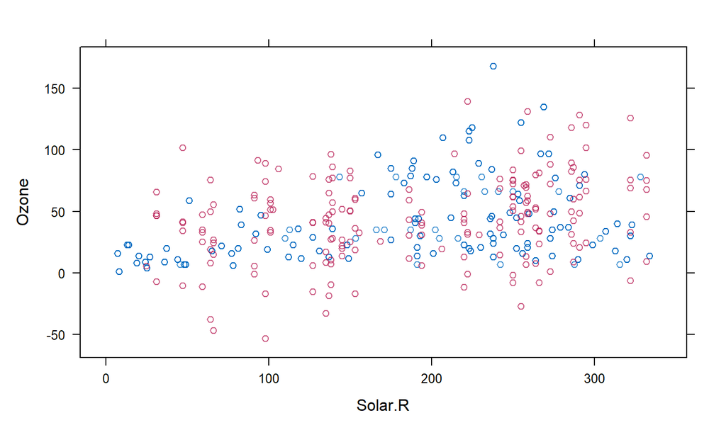

```r
imp_breg <- mice(airquality %>% select(Ozone, Solar.R), method = "norm", print = F)
xyplot(imp_breg, Ozone ~ Solar.R)
```

## Bayesian regression imputation

### Multivariate

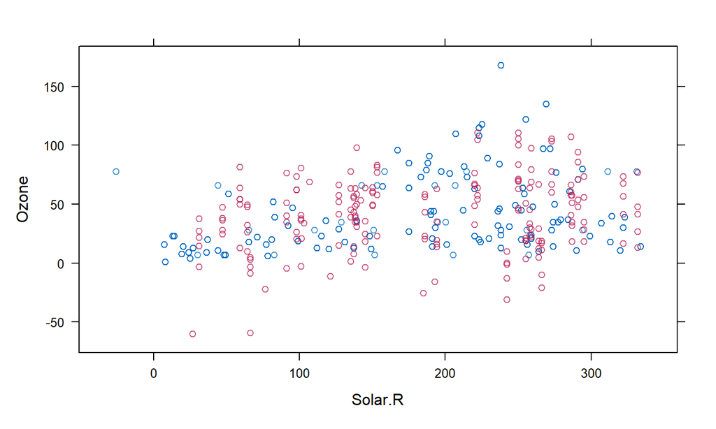

```r
imp_breg <- mice(airquality, method = "norm", print = F)
xyplot(imp_breg, Ozone ~ Solar.R)
```

## Predictive mean matching

### Algorithm

- Estimate the predicted value using Bayesian regression imputation
  - \(Y_{imp} = \dot{\beta}_0 + X_{mis}\dot{\beta}_1 + \epsilon\)
  - Parameters \(\dot{\beta}_0\) and \(\dot{\beta}_1\) are drawn from their posterior distribution.
  - \(\epsilon\) is normally distributed residual error
- Select \(k\) nearest neighbors to this predicted value from the observed data
- Randomly draw one donor to use as imputed value

## Predictive mean matching

### Concept

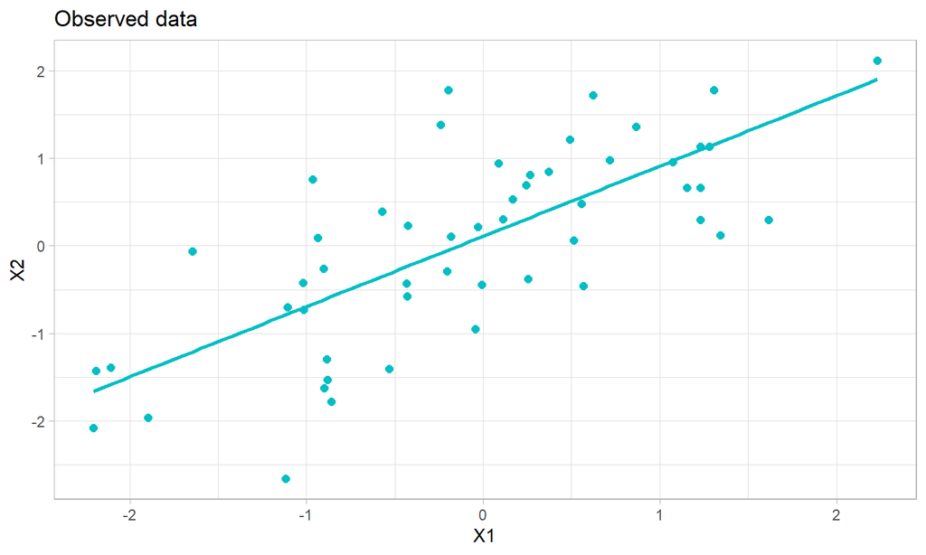

## Predictive mean matching

### Concept

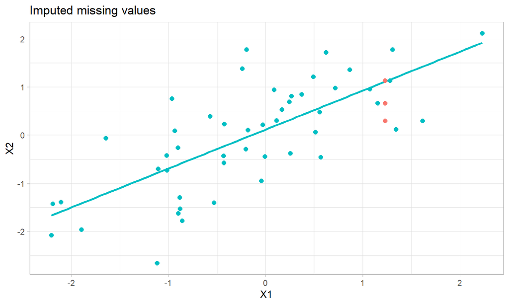

## Predictive mean matching

### Univariate

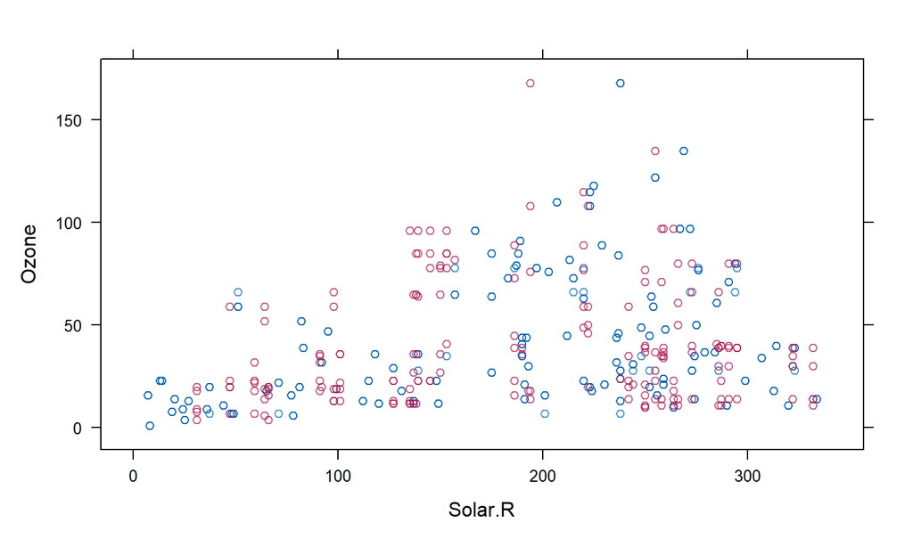

```r
imp_pmm <- mice(airquality %>% select(Ozone, Solar.R), method = "pmm", print = F)
xyplot(imp_pmm, Ozone ~ Solar.R)
```

## Predictive mean matching

### Multivariate

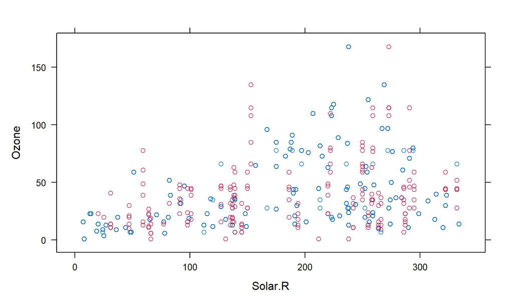

```r
imp_pmm <- mice(airquality, method = "pmm", print = F)
xyplot(imp_pmm, Ozone ~ Solar.R)
```

## Methods for categorical data

- Bayesian logistic regression: `logreg`
- Bayesian polytomous regression: `polyreg`
- Classification and regression trees: `cart`

## Bayesian logistic regression

### Algorithm

- Imputed value: \(Log\frac{P(Y_{miss})}{1-P(Y_{mis})} = \dot{\beta}_0 + X_{mis}\dot{\beta}_1 + \epsilon\)
- Parameters \(\dot{\beta}_0\) and \(\dot{\beta}_1\) are drawn from their posterior distribution.
- \(\epsilon\) is normally distributed residual error

## Bayesian logistic regression

### Concept

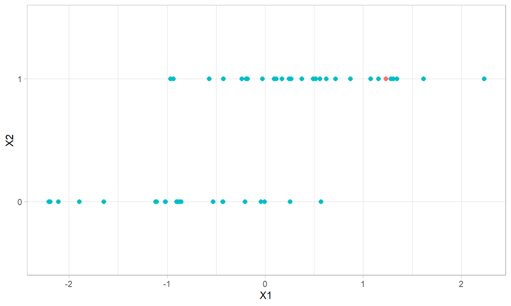

## Bayesian polytomous regression

### Algorithm

- Fit a multinomial regression model.
- Parameters are drawn from their posterior distribution (Bayesian).
- Compute the predicted category.
- Add normally distributed residual error to account for sampling variance.

## Bayesian polytomous regression

### Concept

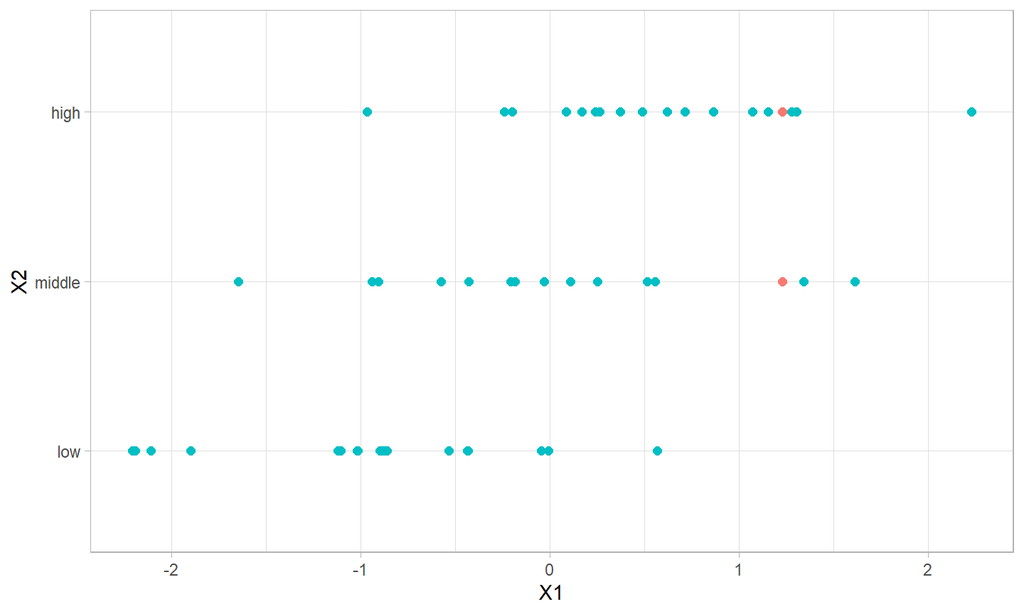

## Classification and regression trees

### Algorithm

- Draw a random bootstrap sample as training set.
- Fit the tree model using the observed data.
- Find the predicted terminal node for the missing value
- Use the observed cases at the predicted terminal node as donors
- Randomly draw the imputed value from the observed donor cases

## Classification and regression trees

### Concept

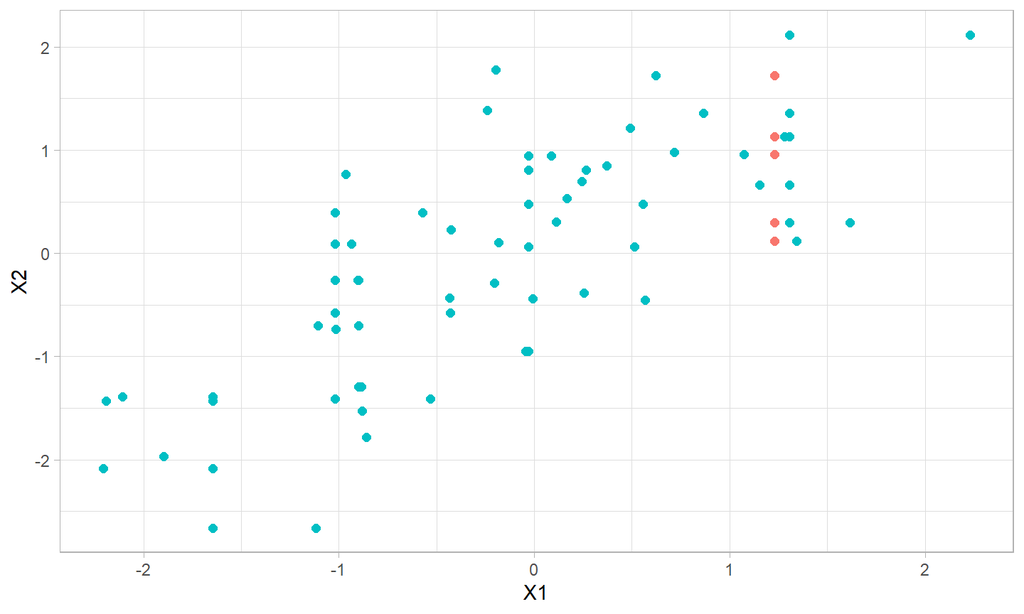

## Classification and regression trees

### Univariate

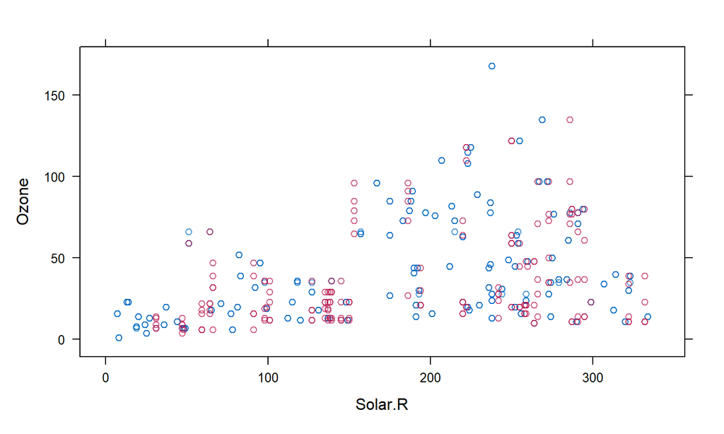

```r
imp_rf <- mice(airquality %>% select(Ozone, Solar.R), method = "cart", print = F)
xyplot(imp_rf, Ozone ~ Solar.R)
```

## Classification and regression trees

### Multivariate

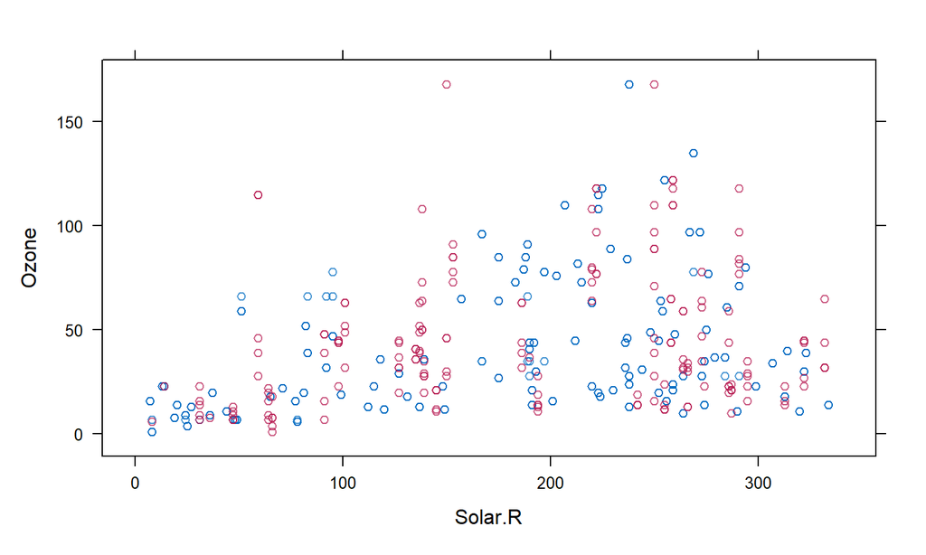

```r
imp_rf <- mice(airquality, method = "cart", print = F)
xyplot(imp_rf, Ozone ~ Solar.R)
```